# Credit Risk via Lending Club

Modern Data Mining Group 39

2022/3/20

# 1 EDA

```r
lending_data <- fread("LoanStats_07_11_Clean.csv")
lending.data.pre = lending_data[,-c("issue_d","funded_amnt","funded_amnt_inv","total_pymnt","total_pymnt_inv","total_rec_prncp","total_rec_int","total_rec_late_fee","recoveries","collection_recovery_fee","last_pymnt_d","last_pymnt_amnt","last_credit_pull_d")]
possible.factor = c("loan_amnt","term","int_rate","grade","home_ownership","annual_inc","dti","verification_status","delinq_2yrs","total_acc","pub_rec","revol_bal","pub_rec_bankruptcies")
```

## 1.1 default vs. grades

As shown in the barplot below, the percentage of fully-paid loans decreases steadily from Grade A to Grade G. Approximately 6% of Grade A loans defaulted whereas 31% of Grade G loans defaulted.

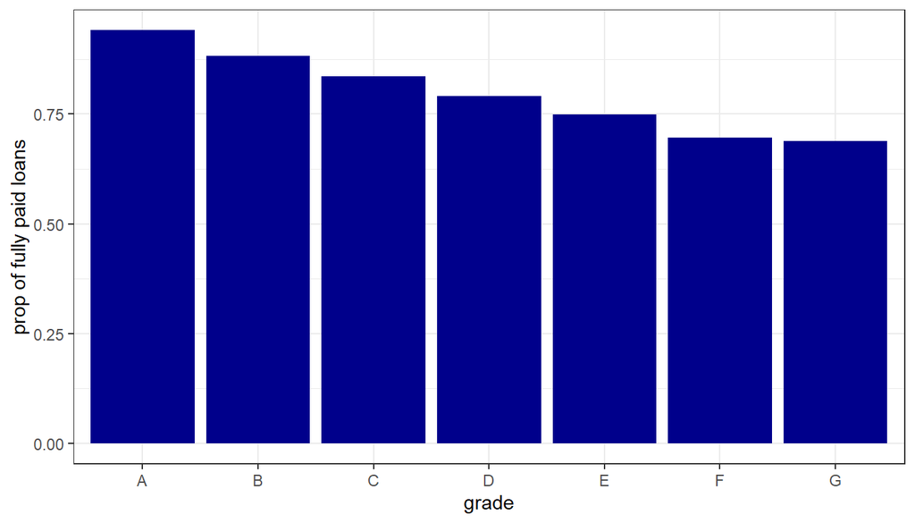

```r
lending.sum = lending_data[order(grade),.(
  fully.paid.prop = length(which(loan_status == "Fully Paid"))/length(loan_status)
),by=grade]

ggplot(data = lending.sum,aes(x=grade,weight=fully.paid.prop))+
  geom_bar(fill = "Darkblue")+
  ylab("prop of fully paid loans")+
  theme_bw()
```

## 1.2 default vs. annual income

```r
income = lending_data %>% group_by(loan_status) %>% summarise(mean(annual_inc))
```

## 1.3 default vs. delinquencies in the past two years

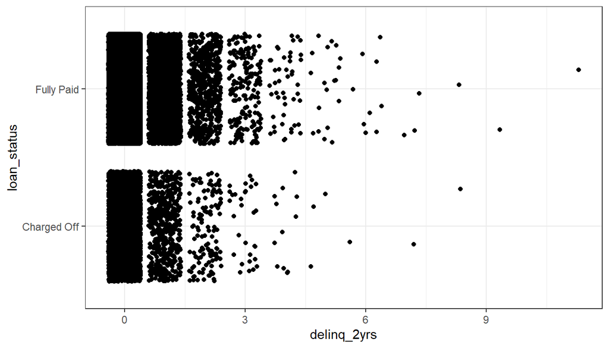

```r
ggplot(data = lending_data,aes(x=delinq_2yrs,y=loan_status))+
  geom_point(position = "jitter")+
  theme_bw()
```

We try to explore the relationship between the loan status and delinquencies in the past two years. The plot seems to be counter-intuitive: past defaults do not seem to predict current defaults.

## 1.4 default vs. interest rate

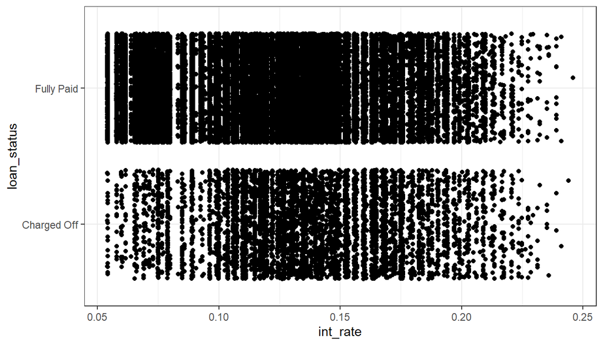

```r
ggplot(data = lending_data,aes(x=int_rate,y=loan_status))+
  geom_point(position = "jitter")+
  theme_bw()
```

```r
income = lending_data %>% group_by(loan_status) %>% summarise(mean(int_rate))
```

It is surprising that the relationship between interest rates and defaults is not as clear as what is predicted in theory: defaulted loans do not seem to have a significantly higher interest rate. Calculation reveals that the mean interest rate for the default group is 0.139 while that for the non-default group is 0.117. This difference is much smaller than the within-group difference, indicating that there are more risk factors to identify. Next we will go directly into multiple logistic regression and build a model.

# 2 Multiple Logistic Regression and Classification

We first manually identify 13 covariates which have a big possibility to be correlated with defaults. We will only include these variables into our model for a better interpretation.

Before building the model, we first put aside 9,000 observations as the testing set. We will build our model with the rest of the observations and select the best one by comparing the real testing error.

```r
set.seed(1)
lending.data.pre[,loan_status := as.numeric(loan_status == "Charged Off")]
lending.data.pre[,term := substr(term,1,2)]
test.num = sample(1:nrow(lending.data.pre),9000,replace = F)
data.test = lending.data.pre[test.num]
data.train = lending.data.pre[-test.num]
```

```r
data = select(data.train,all_of(c(possible.factor,"loan_status")))
```

```r
model = glm(loan_status~.,data = data)
# Anova(model)

data[,":="(verification_status = NULL,delinq_2yrs = NULL,total_acc = NULL,revol_bal = NULL)]

model1 = glm(loan_status~.,data = data)
# Anova(model1)

data[,":="(pub_rec_bankruptcies= NULL,home_ownership = NULL)]
model2 = glm(loan_status~.,data = data)
# Anova(model2)

data[,":="(grade = NULL)]
model3 = glm(loan_status~.,data = data)
# Anova(model3)
```

```r
stargazer(model3,header=FALSE, type=output_format,no.space = T,omit = "addr_state")
```

|  | *Dependent variable:* |
| --- | --- |
|  | loan_status |
| loan_amnt | -0.00000** |
|  | (0.00000) |
| term60 | 0.073*** |
|  | (0.005) |
| int_rate | 1.461*** |
|  | (0.060) |
| annual_inc | -0.00000*** |
|  | (0.00000) |
| dti | 0.001** |
|  | (0.0003) |
| pub_rec | 0.053*** |
|  | (0.008) |
| Constant | -0.040*** |
|  | (0.008) |
| Observations | 29,971 |
| Log Likelihood | -9,919.000 |
| Akaike Inf. Crit. | 19,853.000 |
| *Note:* | p<0.1; p<0.05; p<0.01 |

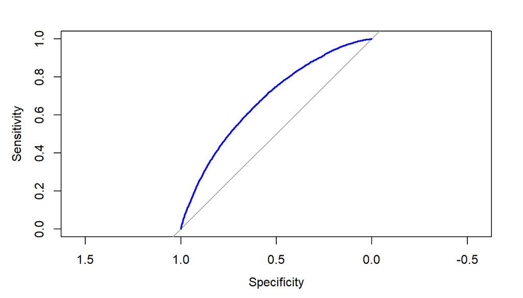

```r
roc.fit1 = roc(data.train$loan_status,model3$fitted.values,plot=T,col="blue")
```

The ROC curve of our model is presented below. The value of the AUC is 0.681.

## 2.1 Classification

```r
ratio1 = 1/2
thres1 = ratio1/(1+ratio1)
class1 = ifelse(model3$fitted.values>thres1,1,0)
confu1 = confusionMatrix(as.factor(class1),reference = as.factor(data$loan_status),positive = "1")
mce1 = (confu1$table[1,2]*2+confu1$table[2,1])/nrow(data)
```

By setting the loss ratio to 1/2, the misclassification error we get from the training data: 0.2758. The threshold for the logit we choose: 0.3333.

```r
test.prob = predict(model3,data.test,type = "response")
class.test = ifelse(test.prob>thres1,1,0)
confu.test = confusionMatrix(as.factor(class.test),reference = as.factor(data.test$loan_status),positive = "1")
mce.test = (confu.test$table[1,2]*2+confu.test$table[2,1])/nrow(data.test)
```

Let’s interprete our model results. `loan amount`, `annual income` are negatively correlated with defaults, while term length, interest rate, dti and derogatory public records are positively correalted with defaults. It indicates that we should value more on the former covariates and consider more about the latter covariates when making investments.

# 3 Decision Tree

```r
tree_data <- lending_data %>% select(c(loan_status, dti, delinq_2yrs,  inq_last_6mths, revol_util, revol_bal, open_acc, pub_rec, total_acc, pub_rec_bankruptcies))
tree_data$loan_status <- as.factor(tree_data$loan_status)
```

Create a function that splits data into train and test sets

```r
create_train_test <- function(data, size = 0.8, train = TRUE) {
    n_row = nrow(data)
    total_row = size * n_row
    train_sample <- 1: total_row
    if (train == TRUE) {
        return (data[train_sample, ])
    } else {
        return (data[-train_sample, ])
    }
}
```

Split the Data into train/test set

```r
data_train <- create_train_test(tree_data, 0.8, train = TRUE)
data_test <- create_train_test(tree_data, 0.8, train = FALSE)
dim(data_train)
```

```
## [1] 31176    10
```

```r
prop.table(table(data_train$loan_status))
```

```
##
## Charged Off  Fully Paid
##      0.1447      0.8553
```

```r
prop.table(table(data_test$loan_status))
```

```
##
## Charged Off  Fully Paid
##      0.1229      0.8771
```

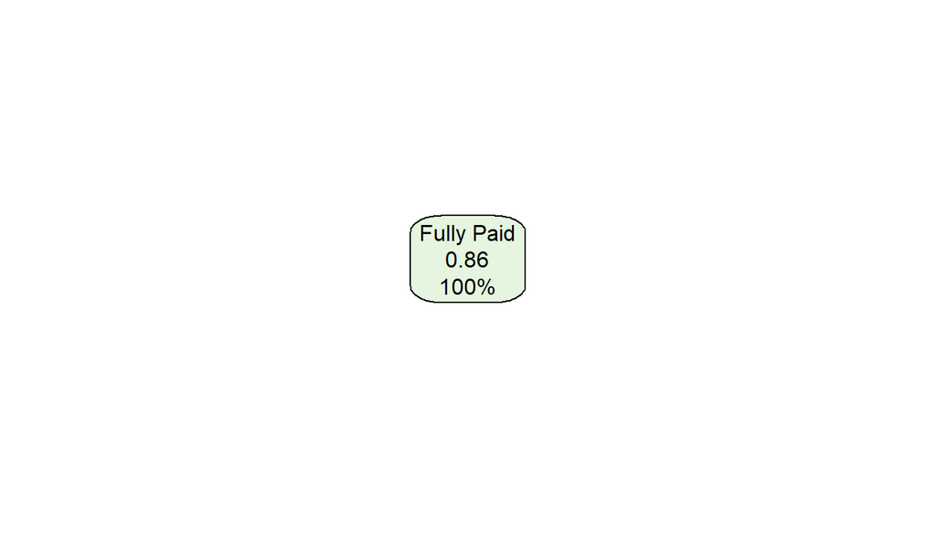

```r
fit_tree <- rpart(loan_status~., data = data_train, method = "class", minsplit = 2, maxdepth=8)
rpart.plot(fit_tree)
```

# 4 Random forest

```r
model_rf = randomForest::randomForest(loan_status~., data_train, method = "class", mtry = 5)
model_rf
table(predict(model_rf,data_test,type = "response") > (1/2.2)/(1+(1/2.2)),
    data_test$loan_status)
rf_ROC = pROC::roc(as.integer(data_test$loan_status), predict(model_rf,newdata = data_test,type = "response"))
print(pROC::auc(rf_ROC))
```

[output not shown]

```r
tree_ROC = pROC::roc(as.integer(data_test$loan_status), predict(model_tree,newdata = data_test,type = "prob")[,2] )
print(pROC::auc(tree_ROC))
```

[output not shown]